# Setup and Context

### Introduction

On November 27, 1895, Alfred Nobel signed his last will in Paris. When it was opened after his death, the will caused a lot of controversy, as Nobel had left much of his wealth for the establishment of a prize.

Alfred Nobel dictates that his entire remaining estate should be used to endow “prizes to those who, during the preceding year, have conferred the greatest benefit to humankind”.

Every year the Nobel Prize is given to scientists and scholars in the categories chemistry, literature, physics, physiology or medicine, economics, and peace.

[figure not shown]

Let's see what patterns we can find in the data of the past Nobel laureates. What can we learn about the Nobel prize and our world more generally?

### Upgrade plotly (only Google Colab Notebook)

Google Colab may not be running the latest version of plotly. If you're working in Google Colab, uncomment the line below, run the cell, and restart your notebook server.

### Read the Data

|  | year | category | prize | motivation | prize_share | laureate_type | full_name | birth_date | birth_city | birth_country | birth_country_current | sex | organization_name | organization_city | organization_country | ISO |
| --- | --- | --- | --- | --- | --- | --- | --- | --- | --- | --- | --- | --- | --- | --- | --- | --- |
| 0 | 1901 | Chemistry | The Nobel Prize in Chemistry 1901 | "in recognition of the extraordinary services ... | 1/1 | Individual | Jacobus Henricus van 't Hoff | 1852-08-30 | Rotterdam | Netherlands | Netherlands | Male | Berlin University | Berlin | Germany | NLD |
| 1 | 1901 | Literature | The Nobel Prize in Literature 1901 | "in special recognition of his poetic composit... | 1/1 | Individual | Sully Prudhomme | 1839-03-16 | Paris | France | France | Male | NaN | NaN | NaN | FRA |

Caveats: The exact birth dates for Michael Houghton, Venkatraman Ramakrishnan, and Nadia Murad are unknown. I've substituted them with mid-year estimate of July 2nd.

### Dataset Dimensions and Time Range

```
<class 'pandas.core.frame.DataFrame'>
RangeIndex: 962 entries, 0 to 961
Data columns (total 16 columns):
 #   Column                 Non-Null Count  Dtype
---  ------                 --------------  -----
 0   year                   962 non-null    int64
 1   category               962 non-null    object
 2   prize                  962 non-null    object
 3   motivation             874 non-null    object
 4   prize_share            962 non-null    object
 5   laureate_type          962 non-null    object
 6   full_name              962 non-null    object
 7   birth_date             934 non-null    object
 8   birth_city             931 non-null    object
 9   birth_country          934 non-null    object
 10  birth_country_current  934 non-null    object
 11  sex                    934 non-null    object
 12  organization_name      707 non-null    object
 13  organization_city      707 non-null    object
 14  organization_country   708 non-null    object
 15  ISO                    934 non-null    object
dtypes: int64(1), object(15)
memory usage: 120.4+ KB
```

### Check for Duplicates

```
np.False_
```

### Check for NaN Values

```
np.True_
```

```
year                       0
category                   0
prize                      0
prize_share                0
laureate_type              0
full_name                  0
birth_date                28
birth_country             28
birth_country_current     28
sex                       28
ISO                       28
birth_city                31
motivation                88
organization_country     254
organization_name        255
organization_city        255
dtype: int64
```

|  | full_name | birth_date |
| --- | --- | --- |
| 24 | Institut de droit international (Institute of International Law) | NaN |
| 60 | Bureau international permanent de la Paix (Permanent International Peace Bureau) | NaN |
| 89 | Comité international de la Croix Rouge (International Committee of the Red Cross) | NaN |
| 200 | Office international Nansen pour les Réfugiés (Nansen International Office for Refugees) | NaN |
| 215 | Comité international de la Croix Rouge (International Committee of the Red Cross) | NaN |

|  | year | category | full_name | birth_city | birth_country | birth_country_current |
| --- | --- | --- | --- | --- | --- | --- |
| 725 | 2001 | Literature | Sir Vidiadhar Surajprasad Naipaul | NaN | Trinidad | Trinidad |
| 837 | 2010 | Peace | Liu Xiaobo | NaN | China | China |
| 957 | 2020 | Medicine | Michael Houghton | NaN | United Kingdom | United Kingdom |

|  | full_name | category | organization_country | organization_city | organization_name |
| --- | --- | --- | --- | --- | --- |
| 627 | Kary B. Mullis | Chemistry | United States of America | La Jolla, CA | NaN |
| 705 | Martinus J.G. Veltman | Physics | Netherlands | Bilthoven | NaN |
| 721 | William S. Knowles | Chemistry | United States of America | St. Louis, MO | NaN |
| 777 | J. Robin Warren | Medicine | Australia | Perth | NaN |
| 831 | Richard F. Heck | Chemistry | United States of America | NaN | University of Delaware |

### Type Conversions and Feature Engineering

Parsing `birth_date` to datetime enables age calculations. The `prize_share` fraction (e.g. `1/2`) is converted to a decimal percentage to support yearly share trend analysis.

#### Convert Year and Birth Date to Datetime

```
The birth_date entries are datatype:
---datetime64[ns]---
```

#### Add a Column with the Prize Share as a Percentage

|  | year | category | prize | motivation | prize_share | laureate_type | full_name | birth_date | birth_city | birth_country | birth_country_current | sex | organization_name | organization_city | organization_country | ISO |
| --- | --- | --- | --- | --- | --- | --- | --- | --- | --- | --- | --- | --- | --- | --- | --- | --- |
| 0 | 1901 | Chemistry | The Nobel Prize in Chemistry 1901 | "in recognition of the extraordinary services ... | 1/1 | Individual | Jacobus Henricus van 't Hoff | 1852-08-30 | Rotterdam | Netherlands | Netherlands | Male | Berlin University | Berlin | Germany | NLD |
| 1 | 1901 | Literature | The Nobel Prize in Literature 1901 | "in special recognition of his poetic composit... | 1/1 | Individual | Sully Prudhomme | 1839-03-16 | Paris | France | France | Male | NaN | NaN | NaN | FRA |

|  | year | category | prize | motivation | prize_share | laureate_type | full_name | birth_date | birth_city | birth_country | birth_country_current | sex | organization_name | organization_city | organization_country | ISO | share_pct |
| --- | --- | --- | --- | --- | --- | --- | --- | --- | --- | --- | --- | --- | --- | --- | --- | --- | --- |
| 0 | 1901 | Chemistry | The Nobel Prize in Chemistry 1901 | "in recognition of the extraordinary services ... | 1/1 | Individual | Jacobus Henricus van 't Hoff | 1852-08-30 | Rotterdam | Netherlands | Netherlands | Male | Berlin University | Berlin | Germany | NLD | 100.00 |

# Plotly Donut Chart: Percentage of Male vs. Female Laureates

```
sex
Male      876
Female     58
Name: count, dtype: int64
```

## The First Three Female Nobel Laureates

|  | year | category | full_name | birth_city | birth_country |
| --- | --- | --- | --- | --- | --- |
| 18 | 1903 | Physics | Marie Curie, née Sklodowska | Warsaw | Russian Empire (Poland) |
| 29 | 1905 | Peace | Baroness Bertha Sophie Felicita von Suttner, n... | Prague | Austrian Empire (Czech Republic) |
| 51 | 1909 | Literature | Selma Ottilia Lovisa Lagerlöf | Mårbacka | Sweden |

Six winners have received the Nobel Prize more than once — including Marie Curie (Physics 1903, Chemistry 1911) and Linus Pauling (Chemistry 1954, Peace 1962).

```
There are 6 winners who were awarded the prize more than once.
```

|  | year | category | laureate_type | full_name |
| --- | --- | --- | --- | --- |
| 18 | 1903 | Physics | Individual | Marie Curie, née Sklodowska |
| 62 | 1911 | Chemistry | Individual | Marie Curie, née Sklodowska |
| 89 | 1917 | Peace | Organization | Comité international de la Croix Rouge (Intern... |
| 215 | 1944 | Peace | Organization | Comité international de la Croix Rouge (Intern... |
| 278 | 1954 | Chemistry | Individual | Linus Carl Pauling |
| 283 | 1954 | Peace | Organization | Office of the United Nations High Commissioner... |
| 297 | 1956 | Physics | Individual | John Bardeen |
| 306 | 1958 | Chemistry | Individual | Frederick Sanger |
| 340 | 1962 | Peace | Individual | Linus Carl Pauling |
| 348 | 1963 | Peace | Organization | Comité international de la Croix Rouge (Intern... |
| 424 | 1972 | Physics | Individual | John Bardeen |
| 505 | 1980 | Chemistry | Individual | Frederick Sanger |
| 523 | 1981 | Peace | Organization | Office of the United Nations High Commissioner... |

```
Comité international de la Croix Rouge (International Committee of the Red Cross) --— Peace (1917), Peace (1944), Peace (1963)
Frederick Sanger --— Chemistry (1958), Chemistry (1980)
John Bardeen --— Physics (1956), Physics (1972)
Linus Carl Pauling --— Chemistry (1954), Peace (1962)
Marie Curie, née Sklodowska --— Physics (1903), Chemistry (1911)
Office of the United Nations High Commissioner for Refugees (UNHCR) --— Peace (1954), Peace (1981)
```

Prizes are awarded across six categories. Medicine leads with 222 prizes; Economics, introduced in 1969, has the fewest at 86.

```
6
```

```
category
Medicine      222
Physics       216
Chemistry     186
Peace         135
Literature    117
Economics      86
Name: count, dtype: int64
```

### The Economics Prize — Awarded from 1969

Unlike the original five categories dating to 1901, the Economics prize was first awarded in 1969 to Jan Tinbergen and Ragnar Frisch.

```
<class 'pandas.core.frame.DataFrame'>
RangeIndex: 962 entries, 0 to 961
Data columns (total 17 columns):
 #   Column                 Non-Null Count  Dtype
---  ------                 --------------  -----
 0   year                   962 non-null    int64
 1   category               962 non-null    object
 2   prize                  962 non-null    object
 3   motivation             874 non-null    object
 4   prize_share            962 non-null    object
 5   laureate_type          962 non-null    object
 6   full_name              962 non-null    object
 7   birth_date             934 non-null    datetime64[ns]
 8   birth_city             931 non-null    object
 9   birth_country          934 non-null    object
 10  birth_country_current  934 non-null    object
 11  sex                    934 non-null    object
 12  organization_name      707 non-null    object
 13  organization_city      707 non-null    object
 14  organization_country   708 non-null    object
 15  ISO                    934 non-null    object
 16  share_pct              962 non-null    float64
dtypes: datetime64[ns](1), float64(1), int64(1), object(14)
memory usage: 127.9+ KB
```

|  | category | year | full_name |
| --- | --- | --- | --- |
| 393 | Economics | 1969 | Jan Tinbergen |
| 394 | Economics | 1969 | Ragnar Frisch |
| 402 | Economics | 1970 | Paul A. Samuelson |

Peace and Literature show the highest proportion of female laureates. Physics has the lowest: only 4 women among 216 prizes.

|  | category | sex | prize |
| --- | --- | --- | --- |
| 11 | Physics | Male | 212 |
| 7 | Medicine | Male | 210 |
| 1 | Chemistry | Male | 179 |
| 5 | Literature | Male | 101 |
| 9 | Peace | Male | 90 |
| 3 | Economics | Male | 84 |
| 8 | Peace | Female | 17 |
| 4 | Literature | Female | 16 |
| 6 | Medicine | Female | 12 |
| 0 | Chemistry | Female | 7 |
| 10 | Physics | Female | 4 |
| 2 | Economics | Female | 2 |

Prize counts dipped during both World Wars. The rolling average reveals a steady increase from the 1950s onward, partly because more prizes are now shared among multiple recipients.

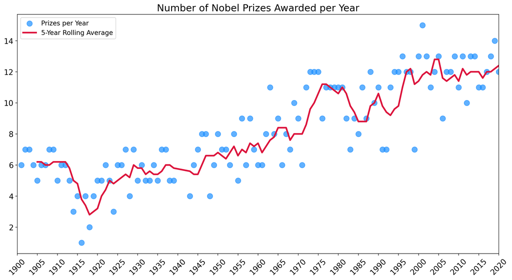

The secondary axis (inverted) plots the 5-year rolling average of prize share percentage. As annual prize counts rise, the average share per laureate falls — prizes are being split more widely.

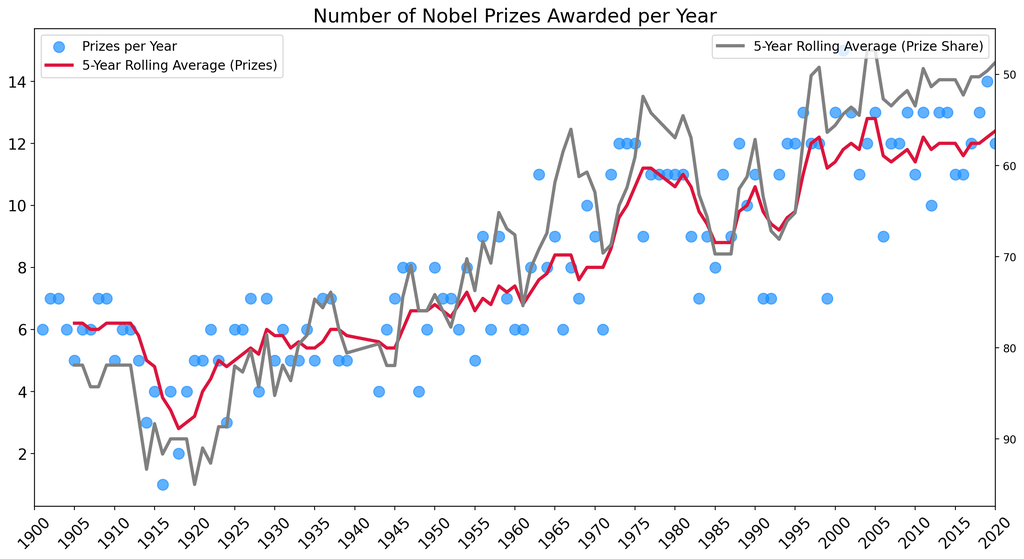

# The Countries with the Most Nobel Prizes

Birth country at current borders is used rather than country at time of birth, reducing distortion from historical boundary changes. The United States leads with 281 prizes — more than twice the UK's 105.

|  | birth_country_current | prize |
| --- | --- | --- |
| 7 | Belgium | 9 |
| 31 | Hungary | 9 |
| 33 | India | 9 |
| 2 | Australia | 10 |
| 20 | Denmark | 12 |
| 54 | Norway | 12 |
| 13 | China | 12 |
| 51 | Netherlands | 18 |
| 3 | Austria | 18 |
| 39 | Italy | 19 |
| 68 | Switzerland | 19 |
| 11 | Canada | 20 |
| 61 | Russia | 26 |
| 40 | Japan | 27 |
| 57 | Poland | 27 |
| 67 | Sweden | 29 |
| 25 | France | 57 |
| 26 | Germany | 84 |
| 73 | United Kingdom | 105 |
| 74 | United States of America | 281 |

# Use a Choropleth Map to Show the Number of Prizes Won by Country

- Create this choropleth map using [the plotly documentation](https://plotly.com/python/choropleth-maps/):

[figure not shown]

- Experiment with [plotly's available colours](https://plotly.com/python/builtin-colorscales/). I quite like the sequential colour `matter` on this map.

Hint: You'll need to use a 3 letter country code for each country.

|  | birth_country_current | ISO | prize |
| --- | --- | --- | --- |
| 74 | United States of America | USA | 281 |
| 73 | United Kingdom | GBR | 105 |
| 26 | Germany | DEU | 84 |
| 25 | France | FRA | 57 |
| 67 | Sweden | SWE | 29 |

Breaking down country totals by category reveals distinct national specialisms. Germany and Japan lag the US most sharply in Economics. France leads Germany in Literature and Peace.

|  | birth_country_current | category | prize |
| --- | --- | --- | --- |
| 204 | United States of America | Medicine | 78 |
| 206 | United States of America | Physics | 70 |
| 201 | United States of America | Chemistry | 55 |
| 202 | United States of America | Economics | 49 |
| 198 | United Kingdom | Medicine | 28 |
| 195 | United Kingdom | Chemistry | 27 |
| 76 | Germany | Physics | 26 |
| 71 | Germany | Chemistry | 26 |
| 200 | United Kingdom | Physics | 24 |
| 205 | United States of America | Peace | 19 |

|  | birth_country_current | category | cat_prize | total_prize |
| --- | --- | --- | --- | --- |
| 109 | India | Physics | 1 | 9 |
| 77 | Hungary | Medicine | 2 | 9 |
| 71 | Hungary | Physics | 2 | 9 |
| 68 | India | Medicine | 2 | 9 |
| 67 | India | Literature | 2 | 9 |

### Number of Prizes Won by Each Country Over Time

- When did the United States eclipse every other country in terms of the number of prizes won?
- Which country or countries were leading previously?
- Calculate the cumulative number of prizes won by each country in every year. Again, use the `birth_country_current` of the winner to calculate this.
- Create a [plotly line chart](https://plotly.com/python/line-charts/) where each country is a coloured line.

The laureate's age in the year of the ceremony is computed from `birth_date` and `year` and stored as `winning_age`.

```
Index(['year', 'category', 'prize', 'motivation', 'prize_share',
       'laureate_type', 'full_name', 'birth_date', 'birth_city',
       'birth_country', 'birth_country_current', 'sex', 'organization_name',
       'organization_city', 'organization_country', 'ISO', 'share_pct',
       'winning_age'],
      dtype='object')
```

|  | year | category | full_name | winning_age |
| --- | --- | --- | --- | --- |
| 0 | 1901 | Chemistry | Jacobus Henricus van 't Hoff | 49.00 |
| 1 | 1901 | Literature | Sully Prudhomme | 62.00 |
| 2 | 1901 | Medicine | Emil Adolf von Behring | 47.00 |
| 3 | 1901 | Peace | Frédéric Passy | 79.00 |
| 4 | 1901 | Peace | Jean Henry Dunant | 73.00 |

Malala Yousafzai is the youngest winner at 17 (Peace, 2014); John Goodenough the oldest at 97 (Chemistry, 2019). The average is approximately 60, with 75% of laureates under 69.

|  | year | category | full_name | winning_age |
| --- | --- | --- | --- | --- |
| 937 | 2019 | Chemistry | John Goodenough | 97.00 |

|  | year | category | full_name | winning_age |
| --- | --- | --- | --- | --- |
| 885 | 2014 | Peace | Malala Yousafzai | 17.00 |

### Descriptive Statistics for the Laureate Age at Time of Award

- Calculate the descriptive statistics for the age at the time of the award.
- Then visualise the distribution in the form of a histogram using [Seaborn's .histplot() function](https://seaborn.pydata.org/generated/seaborn.histplot.html).
- Experiment with the `bin` size. Try 10, 20, 30, and 50.

```
count   934.00
mean     59.95
std      12.62
min      17.00
25%      51.00
50%      60.00
75%      69.00
max      97.00
Name: winning_age, dtype: float64
```

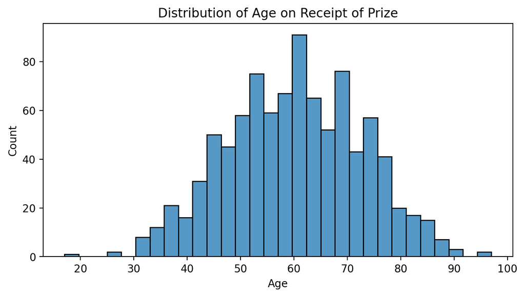

### Age Trend Over Time

The LOWESS trend line shows winning ages around 55–57 in the early 20th century trending toward 65–70 today — consistent with prizes recognising work done decades before the award.

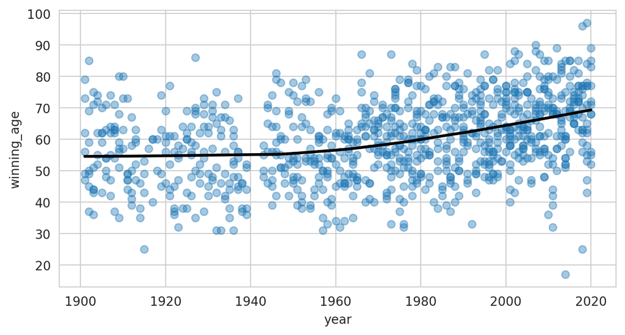

### Winning Age Across the Nobel Prize Categories

How does the age of laureates vary by category?

- Use Seaborn's [`.boxplot()`](https://seaborn.pydata.org/generated/seaborn.boxplot.html?highlight=boxplot#seaborn.boxplot) to show how the mean, quartiles, max, and minimum values vary across categories. Which category has the longest "whiskers"?
- In which prize category are the average winners the oldest?
- In which prize category are the average winners the youngest?

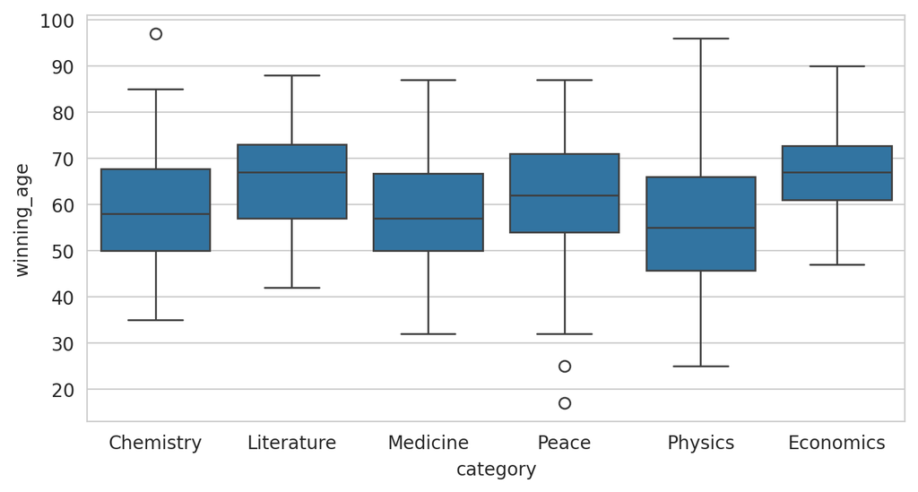

### Age Trends by Category

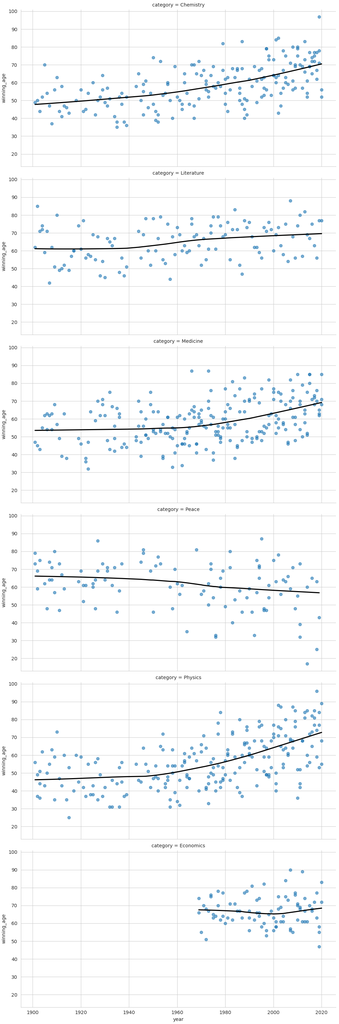

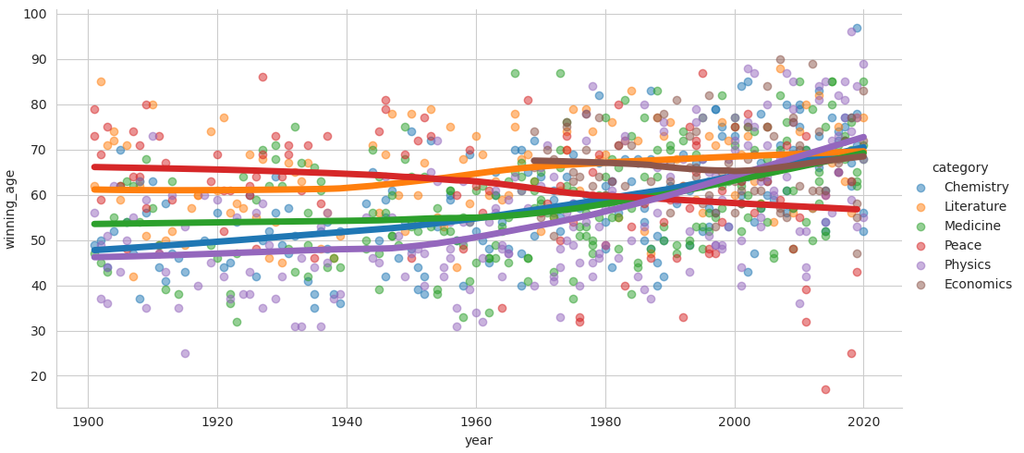